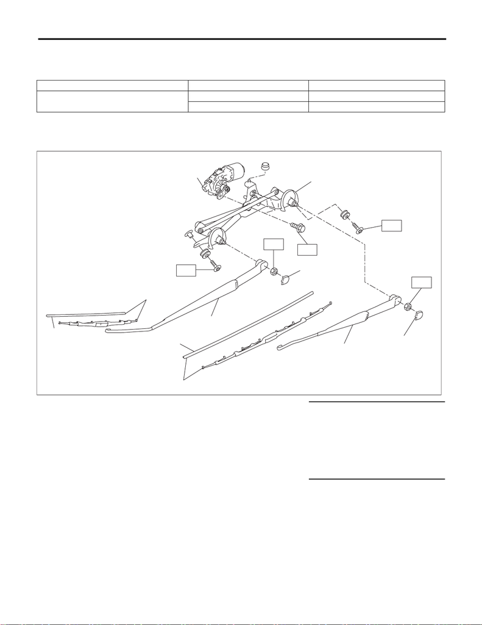

General Description

WIPER AND WASHER SYSTEMS

1. General Description

A: SPECIFICATION

B: COMPONENT

1. FRONT WIPER

Front wiper motor Input 12 V — 72 W or less

Front washer motor

Pump type Centrifugal

Input 12 V — 60 W or less

(1) Motor ASSY - windshield wiper (6) Rubber ASSY - windshield wiper

driver

Tightening torque: N·m (kgf-m, ft-lb)

(2) Link ASSY - windshield wiper (7) Arm ASSY - windshield wiper

assistor

T1: 5.5 (0.6, 4.1)

(3) Cover - windshield wiper arm (8) Blade ASSY - windshield wiper

assistor

T2: 6 (0.6, 4.4)

(4) Arm ASSY - windshield wiper

driver

(9) Rubber ASSY - windshield wiper

assistor

T3: 26 (2.7, 19.2)

(5) Blade ASSY - windshield wiper

driver

(6)

(7)

(8)

(9)

(2)

(3)

(3)

(1)

T3

T3

T2

T1

T1

WW-01108

(5)

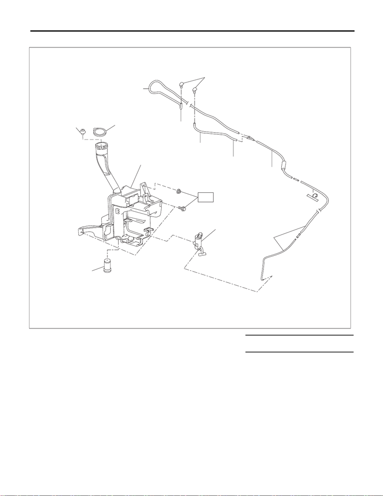

General Description

WIPER AND WASHER SYSTEMS

2. WASHER TANK

(1) Clip (5) Motor pump ASSY - washer front Tightening torque: N·m (kgf-m, ft-lb)

(2) Holder - windshield washer tank (6) Hose - windshield washer T: 6 (0.6, 4.4)

(3) Tank - washer (7) Nozzle - windshield washer

(4) Sensor - washer tank

(6)

WW-01154

(6)

(6)

(6)

(6)

(7)

(3)

(5)

T

(2)

(1)

(4)

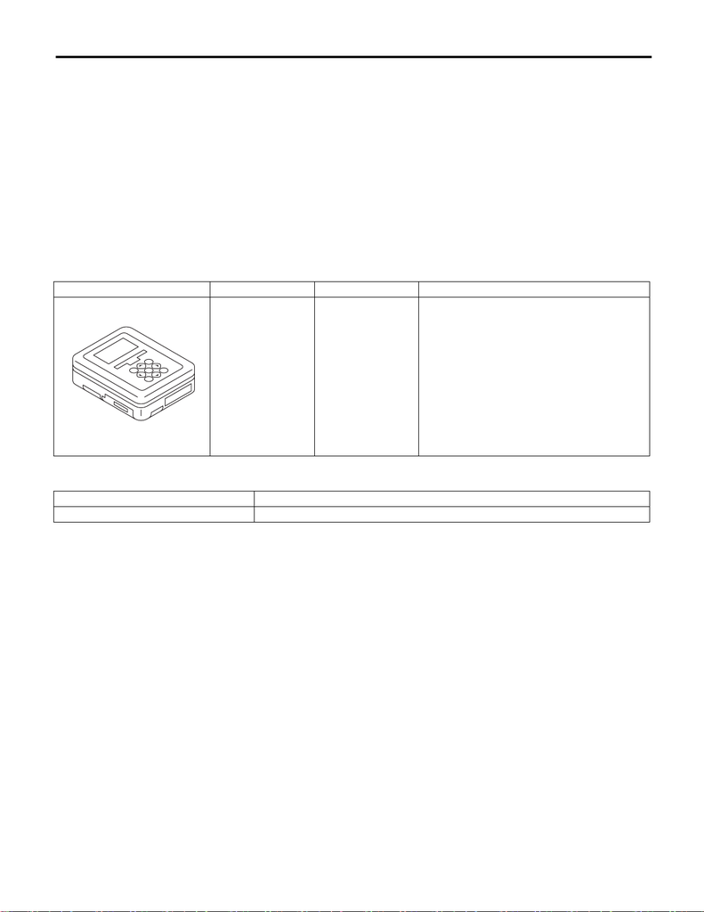

General Description

WIPER AND WASHER SYSTEMS

C: CAUTION

• Be careful of the following items. Failing to do so may cause the airbag system malfunction.

– Yellow connectors and harnesses with yellow tapes around them are the connectors and harnesses for

the airbag system. When using a tester on these circuits, follow the cautions of “AIRBAG SYSTEM”. <Ref.

to AB-9, CAUTION, General Description.>

– Be careful not to damage the airbag system wiring harness when servicing the electrical parts around

the steering column.

• When connecting the pipe hoses, be careful not to cause bend or blockage.

• If even a small amount of silicon oil or grease enters the tank - washer and the washer fluid passages, an

oil film will be formed on the glass and will cause the wiper to chatter and judder. Make sure that no oil comes

into contact with the system.

D: PREPARATION TOOL

1. SPECIAL TOOL

2. GENERAL TOOL

ILLUSTRATION TOOL NUMBER DESCRIPTION REMARKS

1B022XU0 SUBARU SELECT

MONITOR III KIT

Used for setting of each function and trouble-

shooting for electrical system.

TOOL NAME REMARKS

Circuit tester Used for measuring voltage and resistance.

ST1B022XU0